# Half-way data quality assessment

```r
library(data.table)
library(here)
library(magrittr)
library(ggplot2)
library(viridis)
library(binhf)
library(pwr)
library(knitr)
library(kableExtra)
library(cowplot)
```

```r
# Get directory of repository
base_path = here::here()

# Load pre-written functions
source_path = file.path(base_path, 'code', 'utils',
                        fsep = .Platform$file.sep)
source_files = list.files(source_path, pattern = "[.][rR]$",
                          full.names = TRUE, recursive = TRUE)
invisible(lapply(source_files, function(x) source(x)))
```

```r
# Load data
data = Load_data() %>%
  Add_comp(.) %>%
  .[, task_version := as.factor(task_version)]

# get number of participants (to adjust figure height)
n_participants = length(unique(data$participant_id))

# allocate table to hold suspicious participants
sus_pool = data.table()
```

# Data quality

## Errors in forced choices

See if participants made a lot of errors in the forced choice trials. Forced choice trials were very simple: Choose the option that had a frame around it. A lot of errors in these trials indicate the participant did not pay attention to the task at hand.

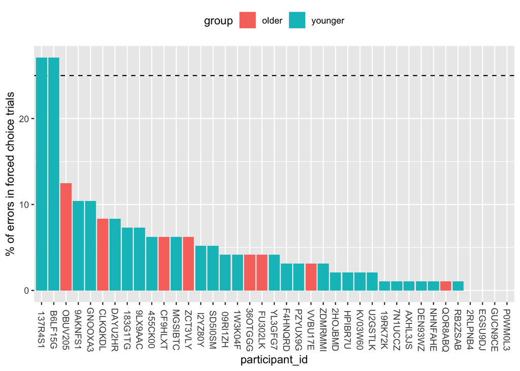

```r
# Set target accuracy of forced choice trials
target_accuracy = 75

# Summary: Mistakes on forced choices
check_fce = data %>%
  .[trial_type == 'forced',] %>%
  .[, forced_error := error] %>%
  .[, .(n_forced = length(forced),
        n_error = sum(as.numeric(forced_error)),
        group = unique(group)), by = 'participant_id'] %>%
  # Percentage false
  .[, perc_forced_error := round((n_error/n_forced) * 100, 2)] %>%
  .[, count := seq(.N), by = c('n_error', 'group')]

check_fce$participant_id = factor(check_fce$participant_id,
                                  levels = check_fce[order(-rank(perc_forced_error))]$participant_id)

# Fill pool with sus participants
sus_pool = check_fce[perc_forced_error > 100 - target_accuracy,
                     c('participant_id', 'group')]
sus_pool$task_version = NA
sus_pool$reason = 'low_forced_accuracy'

p = ggplot(data = check_fce,
           aes(x = participant_id,
               y = perc_forced_error,
               fill = group)) +
  # Add line to mark target of correct answers (everything over line is not accurate enough)
  geom_hline(yintercept = 100 - target_accuracy,
             linetype = 'dashed') +
  geom_col() +
  labs(y = '% of errors in forced choice trials') +
  theme(axis.text.x = element_text(angle = 270, vjust = 0.5),
        legend.position = 'top')
p
```

**Above:** Amount of errors in ‘guided’ choice trials. Dashed line shows 25% errors (75% accuracy). Most participants stay way below this critical error rate. Additionally, older adults don’t seem much worse in this measure.

## Difference estimation bandit 1 and 3

```r
Get_running_avg = function(choice_option, choice_outcome, stim){
  # Initialize array keeping running average for all trials
  running_avg = c()

  # Loop over trials
  for(i in seq(length(choice_option))){
    # Find all choices of option so far
    idx = choice_option[1:i] == stim
    # Create mean over all stim choices so far
    trialwise_mean = mean(choice_outcome[1:i][idx], na.rm = TRUE)
    # Append running average for each trial
    running_avg = c(running_avg, trialwise_mean)
  }

  # Set all trials in which option has not been chosen so far to NA
  running_avg[is.nan(running_avg)] = NA
  return(running_avg)
}

check_est = data %>%
  .[, ':='(avg_1_running = Get_running_avg(choice_option = option_choice,
                                     choice_outcome = outcome,
                                     stim = 1),
           avg_2_running = Get_running_avg(choice_option = option_choice,
                                     choice_outcome = outcome,
                                     stim = 2),
           avg_3_running = Get_running_avg(choice_option = option_choice,
                                     choice_outcome = outcome,
                                     stim = 3)),
    by = c('participant_id', 'task_version')] %>%
  .[, forced_rare := as.numeric(as.logical(is_rare) & trial_type == 'forced' & (comp == '1v2' | comp == '2v3'))] %>%
  .[!is.na(est_1_reward),] %>%
  .[, est_trial := seq(.N), by = c('participant_id', 'task_version')] %>%
  data.table::melt(.,
                   id.vars = c('participant_id',
                               'group',
                               'task_version',
                               'est_trial',
                               'forced_rare'),
                   measure.vars = c('est_1_reward',
                                    'est_1_range',
                                    'avg_1_running',
                                    'est_2_reward',
                                    'est_2_range',
                                    'avg_2_running',
                                    'est_3_reward',
                                    'est_3_range',
                                    'avg_3_running')) %>%
  .[, est_stim := substr(variable, 5, 5)] %>%
  .[, type := substr(variable, 7, 9)] %>%
  .[type == 'rew', type := 'reward'] %>%
  .[type == 'ran', type := 'range'] %>%
  .[type == 'run', type := 'r_avg'] %>%
  data.table::dcast(., participant_id + group + task_version + est_trial + forced_rare + est_stim ~ type,
                    value.var = 'value')

# Create custom t-test that does not throw an error in case all values are the same
# Allows to still run without an error even if participant ALWAYS estimated the same value
my.t.test = function(x, y, alternative, paired){
  obj = try(t.test(x, y, alternative, paired = paired), silent = TRUE)
  if(is(obj, 'try-error')){
    result = list(statistic = as.numeric(NA),
                  parameter = as.numeric(NA),
                  p.value = as.numeric(1))
    return(result)
  } else{
    result = list(statistic = obj$statistic,
                  parameter = obj$parameter,
                  p.value = obj$p.value)
    return(result)
  }
}

# t-test for difference in estimation between bandit 1 and 3
# check_est_1v3 = check_est %>%
#   .[est_stim != 2,] %>%
#   data.table::dcast(participant_id + group + task_version + est_trial ~ paste0('est_', est_stim),
#                     value.var = 'reward') %>%
#   .[, .(mean_1 = mean(est_1),
#         mean_3 = mean(est_3),
#         # Test for sig difference between estimate of bandit 1 and 3 (skip first 3 trials to give time to learn)
#         statistic = my.t.test(x = est_1,
#                               y = est_3,
#                               alternative = 'two.sided',
#                               paired = TRUE)$statistic,
#         parameter = my.t.test(x = est_1,
#                               y = est_3,
#                               alternative = 'two.sided',
#                               paired = TRUE)$parameter,
#         p.value = round(my.t.test(x = est_1,
#                                   y = est_3,
#                                   alternative = 'two.sided',
#                                   paired = TRUE)$p.value, 3)),
#     by = c('participant_id', 'group', 'task_version')]

check_est_1v3 = check_est %>%
  .[est_stim != 2,] %>%
  data.table::dcast(participant_id + group + task_version + est_trial ~ paste0('est_', est_stim),
                    value.var = 'reward') %>%
  .[, .(mean_1 = mean(est_1),
        mean_3 = mean(est_3),
        # Test for sig difference between estimate of bandit 1 and 3 (across task versions is okay because of paired)
        statistic = t.test(x = est_1,
                              y = est_3,
                              alternative = 'less',
                              paired = TRUE)$statistic,
        parameter = t.test(x = est_1,
                              y = est_3,
                              alternative = 'less',
                              paired = TRUE)$parameter,
        p.value = round(t.test(x = est_1,
                                  y = est_3,
                                  alternative = 'less',
                                  paired = TRUE)$p.value, 3)),
    by = c('participant_id', 'group')]

# # Add results to plot
# check_est_diff = check_est %>%
#   .[participant_id %in% check_est_1v3[p.value >= 0.05 & task_version == 1]$participant_id &
#       task_version == 1,
#     diff_est_1v3 := 'no_diff'] %>%
#   .[participant_id %in% check_est_1v3[p.value >= 0.05 & task_version == 2]$participant_id &
#       task_version == 2,
#     diff_est_1v3 := 'no_diff'] %>%
#   .[participant_id %in% check_est_1v3[p.value < 0.05 & task_version == 1]$participant_id &
#       task_version == 1,
#     diff_est_1v3 := 'valid'] %>%
#   .[participant_id %in% check_est_1v3[p.value < 0.05 & task_version == 2]$participant_id &
#       task_version == 2,
#     diff_est_1v3 := 'valid'] %>%
#   .[est_stim != 2]

# Add results to plot
check_est_diff = check_est %>%
  .[participant_id %in% check_est_1v3[p.value >= 0.05]$participant_id,
    diff_est_1v3 := 'no_diff'] %>%
  .[participant_id %in% check_est_1v3[p.value < 0.05]$participant_id,
    diff_est_1v3 := 'valid'] %>%
  .[est_stim != 2]

# add suspicious participants
temp = check_est_1v3[p.value > 0.05,
                      c('participant_id', 'group')]
temp$task_version = NA
temp$reason = 'est_1v3_not_different'
sus_pool = rbind(sus_pool, temp)
```

See if participants can’t accurately estimate that bandit 1 and 3 are different. The distributions of bandit 1 and 3 are very different and don’t touch. Not being able to estimate a difference between them indicates the participant did not pay attention to the task at hand.

```r
p = ggplot(data = check_est_diff,
               aes(x = est_trial,
                   y = reward,
                   color = est_stim)) +
  geom_path(aes(y = r_avg),
             linetype = 'dashed',
            alpha = 0.5) +
  geom_point(size = 0.8) +
  geom_path() +
  labs(x = 'Estimation Trial',
       y = 'Estimate') +
  facet_grid(participant_id ~ diff_est_1v3 + task_version) +
  scale_color_viridis(option = 'D', discrete = TRUE) +
  theme(legend.position = 'top')
```

```r
# Add accuracy of 1v3 choices
check_corr_1v3 = data %>%
  .[comp == '1v3' & trial_type == 'choice',] %>%
  .[, trial := seq(.N),
    by = c('participant_id', 'group', 'task_version')] %>%
  .[, corr_outcome := max(c(reward_stim_1, reward_stim_2)),
    by = c('participant_id', 'group', 'task_version', 'trial')] %>%
  .[, corr := corr_outcome == outcome,
    by = c('participant_id', 'group', 'task_version', 'trial')] %>%
  # get accuracy for valid 1v3 trials (timeouts and forced choices excluded)
  .[!is.na(corr), .(corr_1v3 = sum(corr) / length(corr)),
    by = c('participant_id', 'group', 'task_version')]

p_ext = ggplot(data = check_corr_1v3,
               aes(x = task_version,
                   y = corr_1v3)) +
  geom_hline(yintercept = 0.5, linetype = 'dashed') +
  geom_point() +
  facet_grid(participant_id ~ 'corr_1v3')
```

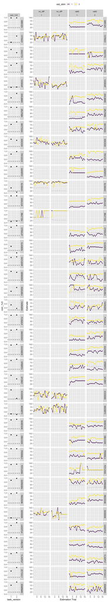

```r
p_full = cowplot::plot_grid(p_ext,p,
                            rel_widths = c(0.3,1),
                            ncol = 2,
                            axis = 'bt',
                            align = 'h')
p_full
```

**Above:** Suspicious and valid estimation patterns of participants. We did a paired t-test across ALL estimation trials (also across task runs) between estimations of bandit 1 and 3. Participants where we cannot find a significant difference between these two bandits using this test are listed in the leftmost two columns of the right plot. These participants estimated similar means for two separate, not-crossing Gaussian distributions. This makes it likely they did not pay attention to the estimation trials. The left plot shows accuracy in comparisons between bandit 1 and 3 in choice trials. Bad performance in estimation and bad performance in choices are mostly aligned, meaning bad performance in estimation seems to not be independent of bad performance in choices.

# Percentage of suspicious participants

```r
length(unique(sus_pool$participant_id)) / length(unique(data$participant_id)) * 100
```

```
## [1] 20.51282
```

Roughly 20% of the 39 participants in this half-way quality assessment get flagged as suspicious (probably did not pay attention).